# Study on Suspicious Web Traffic

Here we can see the most picked champions for all (5) lanes for each team (2 sides, red and blue) I will only present the top 3 since they are much more picked than the rest.

```r
results_per_year[[1]] %>% lapply(\(d){
  d %>% .[order(.$times,decreasing = T),] %>% head(3)
})
```

```
[[1]]
# A tibble: 3 × 2
  blueTopChamp times
  <chr>        <int>
1 Maokai         295
2 Gnar           198
3 Rumble         196

[[2]]
# A tibble: 3 × 2
  blueJungleChamp times
  <chr>           <int>
1 RekSai            370
2 Gragas            238
3 JarvanIV          161

[[3]]
# A tibble: 3 × 2
  blueMiddleChamp times
  <chr>           <int>
1 Viktor            157
2 Azir              154
3 Ahri              121

[[4]]
# A tibble: 3 × 2
  blueADCChamp times
  <chr>        <int>
1 Sivir          301
2 Corki          249
3 Kalista        185

[[5]]
# A tibble: 3 × 2
  blueSupportChamp times
  <chr>            <int>
1 Thresh             297
2 Janna              229
3 Alistar            227

```

[output cut: 24 more lines]

```
[[9]]
# A tibble: 3 × 2
  redADCChamp times
  <chr>       <int>
1 Sivir         337
2 Corki         277
3 Lucian        155

[[10]]
# A tibble: 3 × 2
  redSupportChamp times
  <chr>           <int>
1 Thresh            302
2 Janna             245
3 Alistar           239
```

So as we can see, the most picked champions for

- Top lane: High HP champions, but mostly team-fight utility champions, and Rumble who is a high damaging champion, I assume when the support or jungle fulfills the tank(high HP) role.
- Jungle: Rek’Sai, Gragas and Jarvan IV, which are early-game champions that heavily rely on ganks in the ealy game compared to other junglers, and satisfy the playstyle of pro players as I will talk about later
- Mid lane: Ahri, Viktor and Azir, these are a staple, even today after many new champion releases these 3 still see much light of day in the pro scene as they are heavy hitters, mages, as the mid lane was designed to be and have insane team-fight potential, suitable for the pros. Also insanelly high skill ceiling.
- ADC (Attack Damage Carry): Sivir, Corki and Lucian/Kalista. These are kind of all over the place, as this was and still is the most supported and important role in the game, these guys carry the most potential to win fights and hence, games. So they are subject to ban or some tactics. That’s why here we have a mix mobile champions, wave-clearers, and high damage output
- Support: Thresh, Janna and Alistar. To add to my previous remark about ADCs, these guys play together ini the same lane, the Bot(tom) lane, and there are many known good ADC-Support pairings, that’s why here we can see a bigger mix of champions as well, Janna is an enchanter, healer, shielder, while Alistar is a heavy tank with high HP and engage, Thresh is a mix of everything, he is a perfectly designed champion in my opinion.

Let’s also show now for the other 2 years, 2016 and 2017

```r
#results_per_year[[2]] %>% lapply(\(d){
#  name = names(d)[1]
#  d %>% ggplot() + aes(y=!!sym(name), x = times) + geom_bar(stat="identity", color = "red") +
#  theme(axis.text.y = element_text(hjust = 0.5))
#})
print(2016)
```

```
[1] 2016
```

```r
results_per_year[[2]] %>% lapply(\(d){
  d %>% .[order(.$times,decreasing = T),] %>% head(3)
})
```

```
[[1]]
# A tibble: 3 × 2
  blueTopChamp times
  <chr>        <int>
1 Trundle        290
2 Poppy          269
3 Gnar           200

[[2]]
# A tibble: 3 × 2
  blueJungleChamp times
  <chr>           <int>
1 Elise             496
2 RekSai            487
3 Gragas            402

[[3]]
# A tibble: 3 × 2
  blueMiddleChamp times
  <chr>           <int>
1 Viktor            338
2 Azir              264
3 Vladimir          192

[[4]]
# A tibble: 3 × 2
  blueADCChamp times
  <chr>        <int>
1 Lucian         524
2 Sivir          394
3 Ezreal         385

[[5]]
# A tibble: 3 × 2
  blueSupportChamp times
  <chr>            <int>
1 Braum              579
2 Alistar            381
3 Bard               261

```

[output cut: 24 more lines]

```
[[9]]
# A tibble: 3 × 2
  redADCChamp times
  <chr>       <int>
1 Lucian        537
2 Sivir         416
3 Ezreal        362

[[10]]
# A tibble: 3 × 2
  redSupportChamp times
  <chr>           <int>
1 Braum             528
2 Alistar           452
3 Karma             279
```

```r
#results_per_year[[3]] %>% lapply(\(d){
#  name = names(d)[1]
#  d %>% ggplot() + aes(y=!!sym(name), x = times) + geom_bar(stat="identity", color = "red") +
#  theme(axis.text.y = element_text(hjust = 0.5))
#})
```

```r
print(2017)
```

```
[1] 2017
```

```r
results_per_year[[3]] %>% lapply(\(d){
  d %>% .[order(.$times,decreasing = T),] %>% head(3)
})
```

```
[[1]]
# A tibble: 3 × 2
  blueTopChamp times
  <chr>        <int>
1 Shen           378
2 Rumble         312
3 Maokai         310

[[2]]
# A tibble: 3 × 2
  blueJungleChamp times
  <chr>           <int>
1 Elise             471
2 Khazix            413
3 LeeSin            364

[[3]]
# A tibble: 3 × 2
  blueMiddleChamp times
  <chr>           <int>
1 Orianna           496
2 Syndra            440
3 Taliyah           317

[[4]]
# A tibble: 3 × 2
  blueADCChamp times
  <chr>        <int>
1 Varus          604
2 Ashe           493
3 Jhin           425

[[5]]
# A tibble: 3 × 2
  blueSupportChamp times
  <chr>            <int>
1 Thresh             422
2 Karma              397
3 Lulu               360

```

[output cut: 24 more lines]

```
[[9]]
# A tibble: 3 × 2
  redADCChamp times
  <chr>       <int>
1 Varus         587
2 Ashe          541
3 Jhin          429

[[10]]
# A tibble: 3 × 2
  redSupportChamp times
  <chr>           <int>
1 Karma             436
2 Thresh            421
3 Braum             339
```

As the meta (most effective tactics at the moment) shifts really often in this game, you can see a change in the champions, also, some champions released that year and are available in pro play now, like Bard,Jhin etc. so they get picked.

Now that we have an overall look of what the pros play compared to a normal human who doesn’t care that much about playing which champion, we can dive into win percentages, Let’s see whether there’s a difference of what side a team plays on (red/blue) and what’s each champions win percentage on that side (for a decent amount of games played, let’s put our threshold at 20 minimum).

```r
#rpy_filter <- results_per_year %>% lapply(\(d){
#  lapply(d,\(x){
#    x %>% filter(times>=20)
#  })
#})
#rpy_filter[[1]]
percentage <- \(x,y){
  df$LeagueofLegends %>%
    select(Year,names(x)[1],bResult,rResult) %>%
    filter(Year==y & !!sym(names(x)[1]) %in% x[[1]] & bResult>rResult) %>% group_by(!!sym(names(x)[1])) %>% summarise(wins=n()) %>%
    right_join(x, by=names(x)[1]) %>%
    filter(times>20) %>%
    mutate(win_pct = wins/times * 100)
}
#percentage(results_per_year[[2]][[1]])
#df$LeagueofLegends %>% select(Year,blueTopChamp,bResult,rResult) %>% filter(Year==2015 & blueTopChamp %in% results_per_year[[1]][[1]]$blueTopChamp & bResult>rResult) %>% group_by(blueTopChamp) %>% summarise(wins=n()) %>% right_join(results_per_year[[1]][[1]], by="blueTopChamp") %>% filter(times>20) %>% mutate(win_pct = wins/times * 100)
print("again, first 10 are for 2015, next 10 for 2016, etc.")
```

[output not shown]

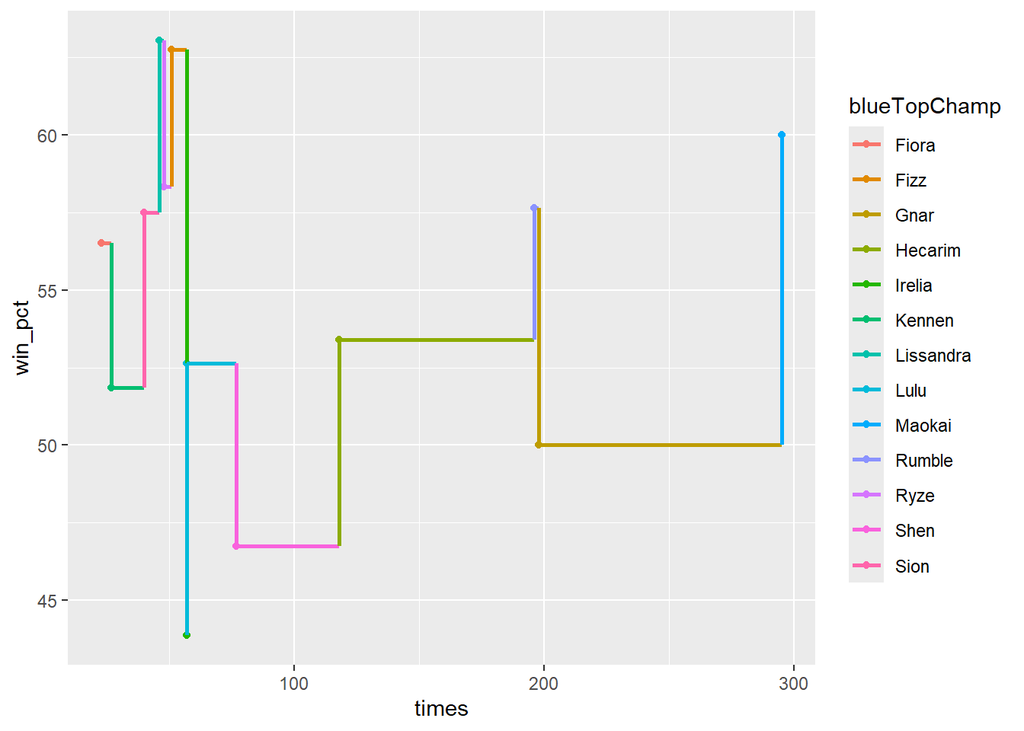

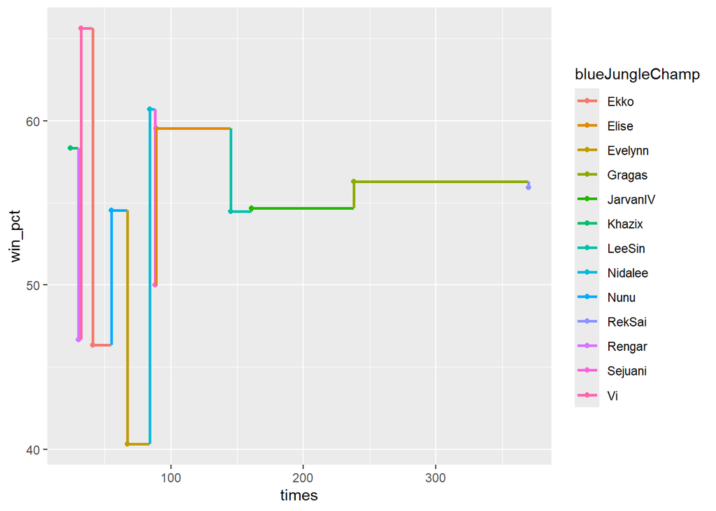

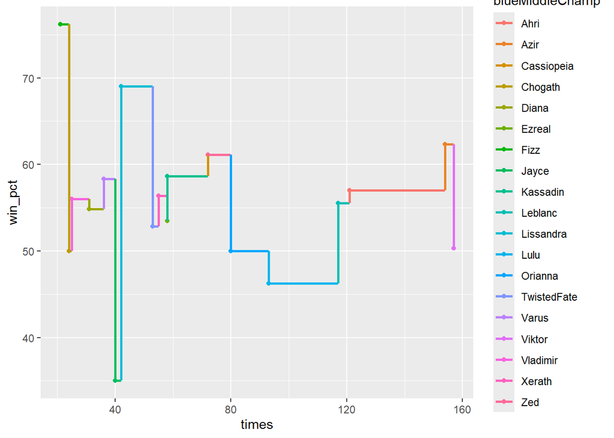

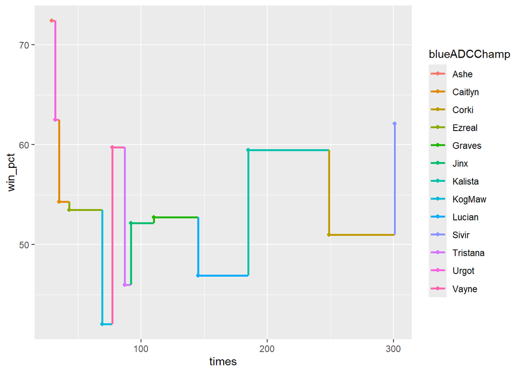

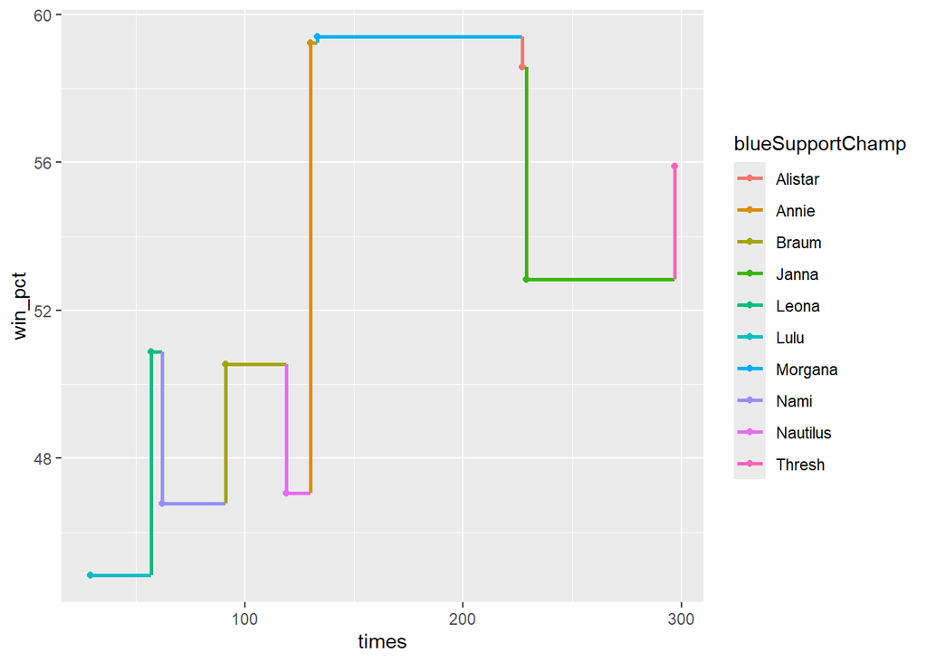

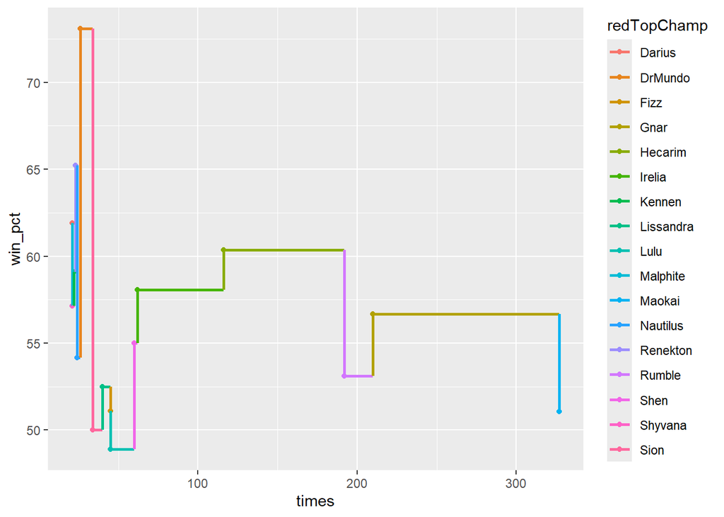

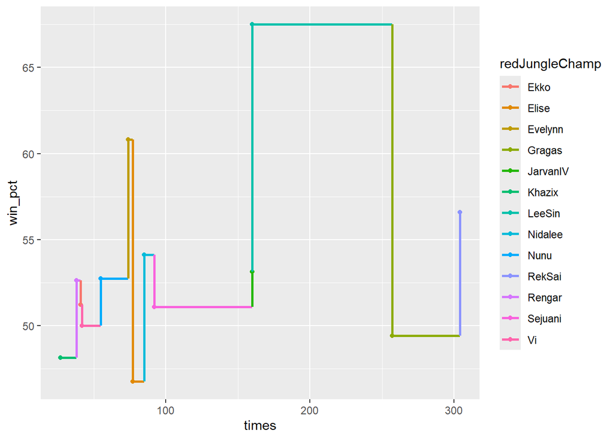

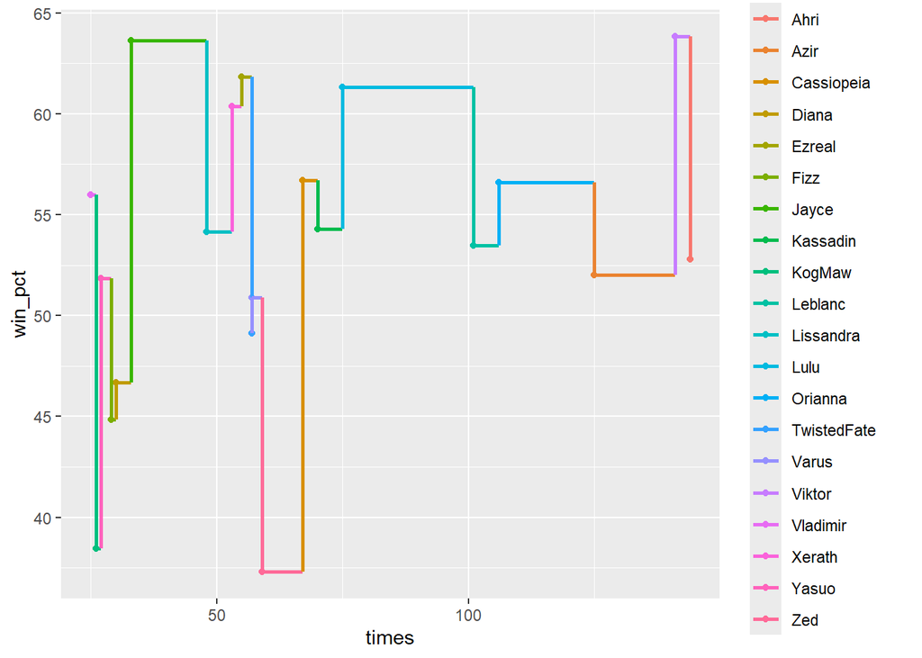

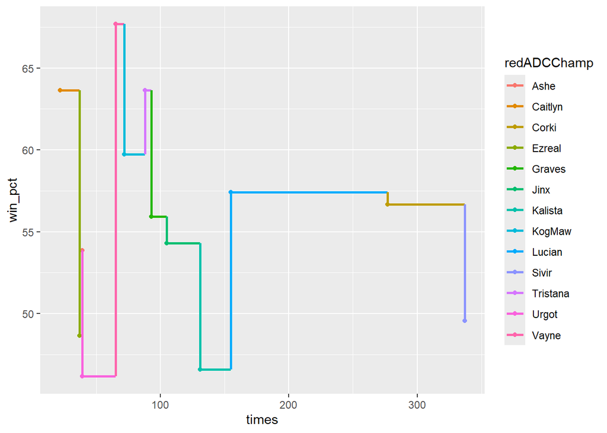

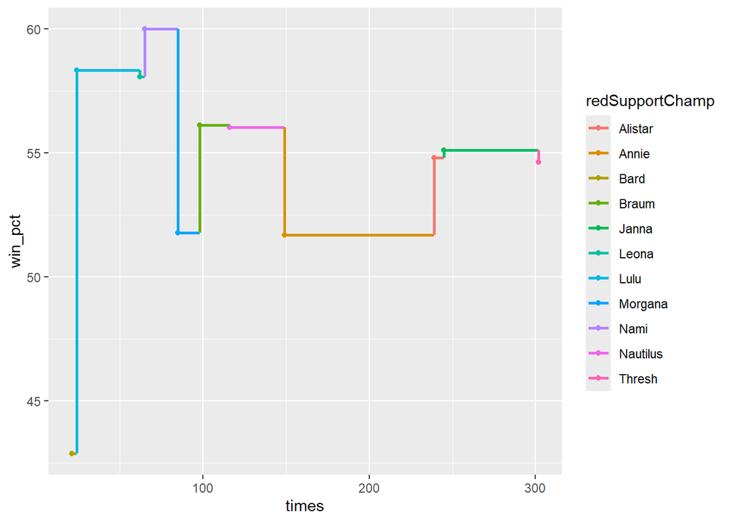

```r
#results_per_year %>% lapply(\(x){
#  lapply(x, \(sl) {percentage(sl)})})
lapply(results_per_year[[1]], \(sl) {percentage(sl,2015)}) -> r1
r1 %>% lapply(\(s){
  name = names(s)[1]
  s %>% ggplot() + aes(x=times, y=win_pct, group =!!sym(name), color=!!sym(name)) +
    geom_point() + geom_step(aes(group=1), size=1)
    #idk what group=1 is but it didn't work without it i though the groups above were enough
  })
```

```r
#lapply(results_per_year[[2]], \(sl) {percentage(sl,2016)})
#lapply(results_per_year[[3]], \(sl) {percentage(sl,2017)})
```

Now, let’s see how kills affect the game, League is a game such that ‘snowballing’ exists, it is a term for gaining early leads and using that to an advantage to keep rolling the game in your favor and gather bigger and bigger advantages over time, just like rolling a snowball. This is a display of some sample of games and where each kill has been taken on the map

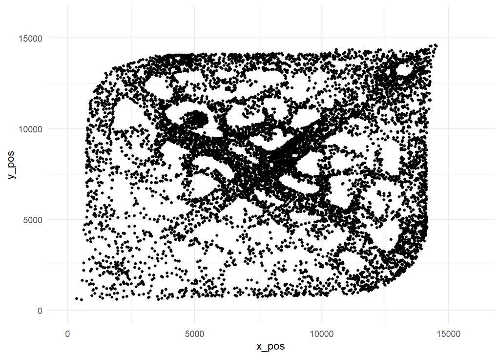

```r
data <- read.csv("./Dataset/kills.csv")
data2 <- read.csv("./Dataset/LeagueofLegends.csv")
data$x_pos <- as.numeric(as.character(data$x_pos))
data$y_pos <- as.numeric(as.character(data$y_pos))
ggplot() +
 geom_point(data = data[1:10000,], aes(x = x_pos, y = y_pos), color = "black", size = 1) +
 theme_minimal() +
 xlim(0, 16000) +
 ylim(0, 16000)
```

```r
#these are the coordinates of the map
print("this is also what the map looks like, the blank points are basically structures on the map, you can not walk over them. The left straight line is top lane, mid lane is obvious, bot lane is the right one")
```

```
[1] "this is also what the map looks like, the blank points are basically structures on the map, you can not walk over them. The left straight line is top lane, mid lane is obvious, bot lane is the right one"
```

Since we talked about snowballing, let’s see how early kill are distributed. And we will also see the difference between red and blue kills *** important mention Blue side is bottom left, red side is top right

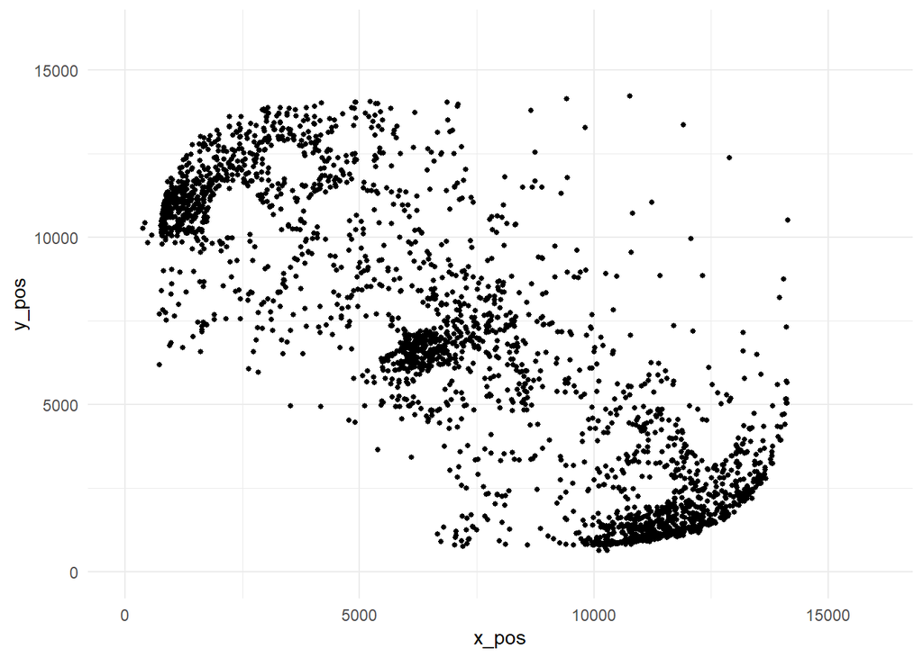

```r
joined_df <- data %>%
 left_join(data2, by = "Address") %>%
 filter(str_starts(Victim, blueTeamTag) & Time<5)
ggplot() +
 geom_point(data = joined_df[1:10000,], aes(x = x_pos, y = y_pos), color = "black", size = 1) +
 theme_minimal() +
 xlim(0, 16000) +
 ylim(0, 16000)
```

```r
print("now for the red side")
```

```
[1] "now for the red side"
```

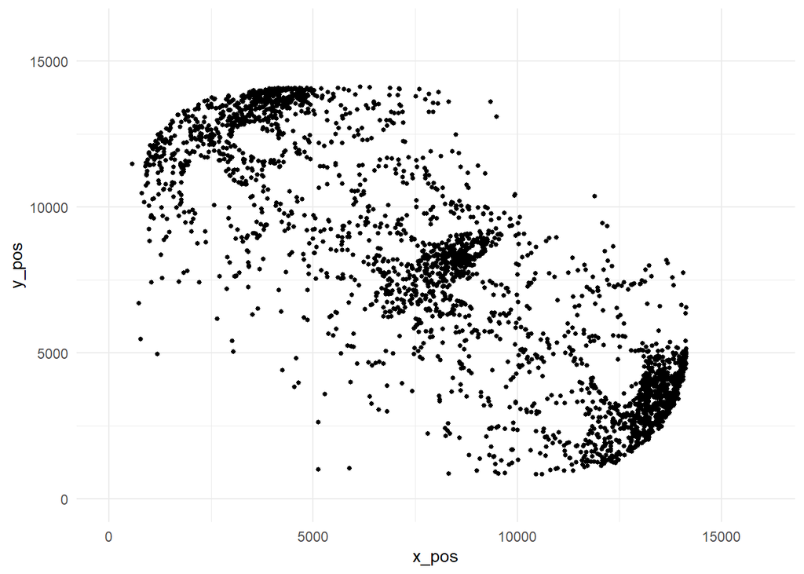

```r
joined_df <- data %>%
 left_join(data2, by = "Address") %>%
 filter(str_starts(Victim, redTeamTag) & Time<5)
ggplot() +
 geom_point(data = joined_df[1:10000,], aes(x = x_pos, y = y_pos), color = "black", size = 1) +
 theme_minimal() +
 xlim(0, 16000) +
 ylim(0, 16000)
```

Naturally, the deaths are scattered a little bit towards the teams respective side, and most of them happen in the lanes, but as you can see there are a lot of kills in between, happening because the time like to skirmish (many vs many battle) in the early game for important objectives, like dragons, monsters and just diving(killing opponents under their turret)

As I’ve mentioned monsters and objectives, it’s good to note that they are one of the most important things in the game, they give a lot of gold, and buffs that help in further fights, so we will check out the win percentage based on the monsters slain.

```r
inner_join(df$LeagueofLegends,df$monsters, by="Address") %>% mutate(winner = ifelse(bResult>rResult,"b","r")) %>% group_by(Address,Team,winner) %>% summarise(count = n())  %>% mutate(Address = str_split(Address,"/",n=7)[[1]][7])  %>% pivot_wider(names_from = "Team", values_from="count") -> partial_result
partial_result %>% head(1000)
```

```
# A tibble: 1,000 × 8
# Groups:   Address [1,000]
   Address            winner bBarons bDragons bHeralds rBarons rDragons rHeralds
   <chr>              <chr>    <int>    <int>    <int>   <int>    <int>    <int>
 1 300266?gameHash=a… b            2        3        1      NA       NA       NA
 2 300276?gameHash=b… r            1        3        1       1        2       NA
 3 300279?gameHash=5… b            2        3       NA      NA        2        1
 4 300317?gameHash=5… r           NA        1       NA       1        1        1
 5 300323?gameHash=4… b            1        3        1      NA        1       NA
 6 300325?gameHash=1… b            2        3        1      NA        2       NA
 7 300584?gameHash=9… b            1        1        1      NA        1       NA
 8 300586?gameHash=d… b            2        2        1      NA        1       NA
 9 300587?gameHash=a… b            2        5       NA      NA       NA        1
10 310214?gameHash=9… r            1        2       NA       1        3        1
# ℹ 990 more rows
```

```r
#here i cut the address string a little so it's clearer
#also i made it wider so we can see better and compare
```

keep in mind here that not all monsters were in the game at the time, some, like elemental dragons and heralds were introduced after 2015 Now that we have the above table let’s compare total monsters slain to wins, whether it affects something at all. But also, note that not all dragons are equal and all objectives are equal as i said above.

```r
partial_result %>% rowwise() %>%
  mutate(
    r_sum = sum(c_across(starts_with("r")& where(is.numeric)), na.rm = TRUE),
    b_sum = sum(c_across(starts_with("b")& where(is.numeric)), na.rm = TRUE)
  ) %>% select(Address,winner,r_sum,b_sum) -> partial_result2
partial_result2 %>% head(200)
```

```
# A tibble: 200 × 4
# Rowwise:  Address
   Address                          winner r_sum b_sum
   <chr>                            <chr>  <int> <int>
 1 300266?gameHash=aa0e58f00d1d18e0 b          0     6
 2 300276?gameHash=bc00457a5072a5a5 r          3     5
 3 300279?gameHash=51eab859e6cb3f6d b          3     5
 4 300317?gameHash=55170dc883a36be7 r          3     1
 5 300323?gameHash=410b4ede6a0de62b b          1     5
 6 300325?gameHash=190bbbfe9aa11560 b          2     6
 7 300584?gameHash=994a9f79d13f42d6 b          1     3
 8 300586?gameHash=d5741db163533909 b          1     5
 9 300587?gameHash=adf333629d99ed10 b          1     7
10 310214?gameHash=986eb7ceaade8aaa r          5     3
# ℹ 190 more rows
```

Here are the winners of games and the total of monsters slain. Lets find the percentage

```r
partial_result2 %>% mutate(more=ifelse(r_sum>b_sum,"r","b")) %>% mutate(expected_winner = ifelse(winner==more,1,0)) %>% ungroup() %>% summarise(exp_win = sum(expected_winner)/n())
```

```
# A tibble: 1 × 1
  exp_win
    <dbl>
1   0.867
```

So about 86.7% of the time the team with more monsters slain wins this games. Now let’s look at SKT, as i promisedsince they were the best team throughout this time, winning 2 out of 3 worlds and losing once in the final.

```r
skt <- df$LeagueofLegends %>% filter(blueTeamTag =="SKT" | redTeamTag=="SKT")
skt %>% head()
```

```
# A tibble: 6 × 57
  League  Year Season Type     blueTeamTag bResult rResult redTeamTag gamelength
  <chr>  <dbl> <chr>  <chr>    <chr>         <dbl>   <dbl> <chr>           <dbl>
1 LCK     2015 Spring Playoffs CJE               1       0 SKT                44
2 LCK     2015 Spring Playoffs SKT               0       1 CJE                32
3 LCK     2015 Spring Playoffs CJE               0       1 SKT                31
4 LCK     2015 Spring Playoffs SKT               1       0 CJE                72
5 LCK     2015 Spring Playoffs SKT               1       0 CJE                35
6 LCK     2015 Spring Playoffs GET               0       1 SKT                36
# ℹ 48 more variables: golddiff <chr>, goldblue <chr>, bKills <chr>,
#   bTowers <chr>, bInhibs <chr>, bDragons <chr>, bBarons <chr>,
#   bHeralds <chr>, goldred <chr>, rKills <chr>, rTowers <chr>, rInhibs <chr>,
#   rDragons <chr>, rBarons <chr>, rHeralds <chr>, blueTop <chr>,
#   blueTopChamp <chr>, goldblueTop <chr>, blueJungle <chr>,
#   blueJungleChamp <chr>, goldblueJungle <chr>, blueMiddle <chr>,
#   blueMiddleChamp <chr>, goldblueMiddle <chr>, blueADC <chr>, …
```

```r
skt %>% mutate(winner=ifelse(blueTeamTag=="SKT" & bResult > rResult,1,ifelse(redTeamTag=="SKT" & rResult > bResult,1,0))) %>% .[,c(1:6,ncol(.))] %>% summarise(total_pct = sum(winner)/n())
```

```
# A tibble: 1 × 1
  total_pct
      <dbl>
1     0.712
```

As we can see they won 71% of all the games they played, which is really good. And let’s see the monsters now

```r
inner_join(skt,df$monsters, by="Address") %>% mutate(winner = ifelse(bResult>rResult,"b","r")) %>% group_by(Address,Team,winner) %>% summarise(count = n())  %>% mutate(Address = str_split(Address,"/",n=7)[[1]][7])  %>% pivot_wider(names_from = "Team", values_from="count") -> pr
pr %>%  rowwise() %>%
  mutate(
    r_sum = sum(c_across(starts_with("r")& where(is.numeric)), na.rm = TRUE),
    b_sum = sum(c_across(starts_with("b")& where(is.numeric)), na.rm = TRUE)
  ) %>% select(Address,winner,r_sum,b_sum) -> pr2
pr2
```

```
# A tibble: 403 × 4
# Rowwise:  Address
   Address                          winner r_sum b_sum
   <chr>                            <chr>  <int> <int>
 1 341202?gameHash=7e08241b059766d7 b          2     2
 2 341204?gameHash=7149ba1eac026c71 r          4     0
 3 341210?gameHash=a4d2422c8da97a91 r          4     0
 4 351146?gameHash=fcd2dc86969dd034 b          0     4
 5 540853?gameHash=3125fd4c4f7124ed b          1     4
 6 540885?gameHash=24216cb12c2f22e7 b          2     4
 7 540892?gameHash=ae1050af224bc9c6 b          4     3
 8 551027?gameHash=2596634c7e953d03 b          3     6
 9 551040?gameHash=aba82d5135e094ec r          4     1
10 80865?gameHash=9c827bc6768fa93d  b          1     4
# ℹ 393 more rows
```

```r
#i just repeated steps for above but just for skt
pr2%>% mutate(more=ifelse(r_sum>b_sum,"r","b")) %>% mutate(expected_winner = ifelse(winner==more,1,0)) %>% ungroup() %>% summarise(exp_win = sum(expected_winner)/n())
```

```
# A tibble: 1 × 1
  exp_win
    <dbl>
1   0.886
```

#Conclusion